# Exploratory Analysis for Future Work

Author

Riccardo Volpato

# Data processing

```r
library(tidyverse)
library(knitr)
library(psych)
```

```r
options(readr.show_col_types = FALSE)
file_path <- "data/shared/TPSai+–+Prolific_CFA+Eval+Demog.csv"
raw_data  <- read_csv(file_path, n_max = 2)
colnames  <- names(raw_data)
q_text    <- setNames(sub(".* - ", "", as.character(raw_data[1, ])), colnames)
raw_data  <- read_csv(file_path, col_names = colnames, skip = 1)
```

```r
questions_map <- read_csv("surveys/cfa_qs.csv")
cols_tpsai_raw  <- sprintf("TPSAI_%d", seq_len(nrow(questions_map)))
```

```r
questions_map |> kable()
```

| ID | 2F | 3F | 4F | Item |
| --- | --- | --- | --- | --- |
| TPSAI_01 | Motivations | Motivations | Cognitive Trust | I trust the AI to provide me information that helps me manage my psychological challenges |
| TPSAI_02 | Motivations | Motivations | Cognitive Trust | I trust the AI to help me clarify my thoughts about a difficult situation |
| TPSAI_03 | Motivations | Motivations | Cognitive Trust | I trust that what the AI tells me about psychological concepts and processes is accurate and reliable |
| TPSAI_04 | Motivations | Motivations | Cognitive Trust | I can rely on the AI to make sense of the perspective of someone I am having difficulties to understand |
| TPSAI_05 | Motivations | Motivations | Cognitive Trust | Using the AI enables me to see how my experiences fit into what is common for others |
| TPSAI_06 | Motivations | Motivations | Cognitive Trust | I trust the AI to understand my specific needs when I ask for support |
| TPSAI_07 | Motivations | Motivations | Cognitive Trust | I trust the AI to give me advice that is well-tailored to my specific situation |
| TPSAI_08 | Motivations | Motivations | Cognitive Trust | I trust that the more information the AI has about me, the better it can support me |
| TPSAI_09 | Motivations | Motivations | Cognitive Trust | I trust the AI to reflect the feelings I share in a way that feels accurate |
| TPSAI_10 | Motivations | Motivations | Affective Trust | I trust the AI to make me feel heard and validated |
| TPSAI_11 | Motivations | Motivations | Affective Trust | I feel calmer when I talk to the AI while distressed |
| TPSAI_12 | Motivations | Motivations | Affective Trust | Talking to the AI about difficult situations leaves me feeling reassured |
| TPSAI_13 | Motivations | Motivations | Affective Trust | I trust that the AI responses do not make me feel discriminated |
| TPSAI_14 | Motivations | Motivations | Affective Trust | I trust the AI to provide me with a space where I can express myself freely |
| TPSAI_15 | Motivations | Motivations | Affective Trust | Opening up to the AI about personal concerns feels safe |
| TPSAI_16 | Concerns | Concerns | Concerns | I am concerned that the AI may not be able to respond appropriately to a mental health crisis (e.g., feeling hopeless, stuck, or wanting to self-harm) |
| TPSAI_17 | Concerns | Concerns | Concerns | I am concerned that the AI does not sufficiently highlight its limitations as a mental health tool |
| TPSAI_18 | Concerns | Concerns | Concerns | I believe the AI may provide inaccurate or misleading mental health information |
| TPSAI_19 | Concerns | Concerns | Concerns | I am concerned that the AI offers psychological advice without sufficient ethical and regulatory accountability |
| TPSAI_20 | Concerns | Concerns | Concerns | I am concerned that the AI company may use my data in ways I do not approve of |
| TPSAI_21 | Concerns | Concerns | Concerns | I am skeptical that the AI company ensures the AI is safe to use for mental health support |
| TPSAI_22 | Concerns | Concerns | Concerns | I am concerned that the values of the AI company do not sufficiently align with my own |
| TPSAI_23 | Concerns | Concerns | Concerns | I am concerned that the AI company treats my wellbeing as secondary to their commercial interests |
| TPSAI_24 | Concerns | Concerns | Concerns | I trust AI responses less as conversations get longer and the AI starts to ‘drift’ (e.g., speaks repetitively or less consistently) |
| TPSAI_25 | Concerns | Concerns | Concerns | I am concerned that the way the AI communicates may lead me to trust it more than I should |
| TPSAI_26 | Concerns | Relational Scepticism | Relational Scepticism | The AI cannot replace human support even when it is limited and difficult to access |
| TPSAI_27 | Concerns | Relational Scepticism | Relational Scepticism | Even though the AI sounds human, our interactions lack a sense of shared presence and experience |
| TPSAI_28 | Concerns | Relational Scepticism | Relational Scepticism | The emotional support the AI can offer is limited by its lack of embodied feelings and shared presence |
| TPSAI_29 | Concerns | Relational Scepticism | Relational Scepticism | While the AI uses empathic language, it does not comprehend and care about my experiences |
| TPSAI_30 | Concerns | Relational Scepticism | Relational Scepticism | Forming an emotional connection with the AI is limited by its lack of genuine feelings and experience |

```r
likert_levels <- c(
  "Strongly disagree"          = 1,
  "Disagree"                   = 2,
  "Somewhat disagree"          = 3,
  "Neither agree nor disagree" = 4,
  "Somewhat agree"             = 5,
  "Agree"                      = 6,
  "Strongly agree"             = 7
)

likert_levels_5 <- c(
  "Strongly disagree"          = 1,
  "Disagree"                   = 2,
  "Neither agree nor disagree" = 3,
  "Agree"                      = 4,
  "Strongly agree"             = 5
)

overall_levels <- c(
  "Not at all"  = 1,
  "Very little" = 2,
  "A little"    = 3,
  "Moderately"  = 4,
  "Quite a bit" = 5,
  "Very much"   = 6,
  "Completely"  = 7
)

freq_levels <- c(
  "Never",
  "About once a month",
  "About once a week to a few times a month",
  "Several times a week",
  "Daily or multiple times a day"
)
```

```r
cols_tpsai <- gsub("^TPSAI_(\\d)$", "TPSAI_0\\1", cols_tpsai_raw)
comp_items    <- sprintf("TPSAI_%02d", c(1:9))
affect_items  <- sprintf("TPSAI_%02d", c(10:15))
risk_items      <- sprintf("TPSAI_%02d", 16:25)
relScept_items      <- sprintf("TPSAI_%02d", 26:30)

item_map <- bind_rows(
  tibble(item = comp_items,   top = "Motivations",    sub = "Competence"),
  tibble(item = affect_items, top = "Motivations",    sub = "Affective"),
  tibble(item = risk_items,     top = "Concerns", sub = "RiskVigilance"),
  tibble(item = relScept_items,     top = "Concerns", sub = "RelationalScepticism")
) |>
  arrange(item)

item_map <- item_map |>
  mutate(sub3 = if_else(top == "Motivations", "Motivations", sub))

trust_items    <- item_map |> filter(top == "Motivations")    |> pull(item)
distrust_items <- item_map |> filter(top == "Concerns") |> pull(item)
```

```r
ptt_items <- sprintf("PTT_%d", 1:6)
etmcq_items <- sprintf("ETMCQ_%d", 1:15)
gaid_items <- sprintf("GAID_%d", 1:11)

eval_data <- raw_data |>
  mutate(across(all_of(cols_tpsai_raw), ~ likert_levels[.x])) |>
  mutate(across(all_of(etmcq_items), ~ likert_levels[.x])) |>
  mutate(across(all_of(gaid_items), ~ likert_levels_5[.x])) |>
  mutate(across(all_of(ptt_items), ~ likert_levels_5[.x])) |>
  rename(all_of(setNames(cols_tpsai_raw, cols_tpsai))) |>
  mutate(
    motivations_score = rowMeans(across(all_of(trust_items))),
    concerns_score = rowMeans(across(all_of(risk_items))),
    rel_scept_score = rowMeans(across(all_of(relScept_items)))
  ) |>
  mutate(
    frequency_level = factor(FREQ, levels = freq_levels, ordered = TRUE),
    frequency_level = as.integer(frequency_level),
    trust_level   = overall_levels[TR],
    distrust_level   = overall_levels[DT]
  ) |>
  mutate(platform =
           coalesce(`PLAT-PSY_11_TEXT`, `PLAT-PSY`, `PLAT-GEN_11_TEXT`, `PLAT-GEN`)) |>
  select(
    all_of(cols_tpsai), motivations_score, concerns_score, rel_scept_score,
    frequency_level, trust_level, distrust_level,
    all_of(ptt_items), all_of(etmcq_items), all_of(gaid_items),
    `PSY-FREQ`, `PSY-SAT`, platform, Age)
```

# Items and factors plots

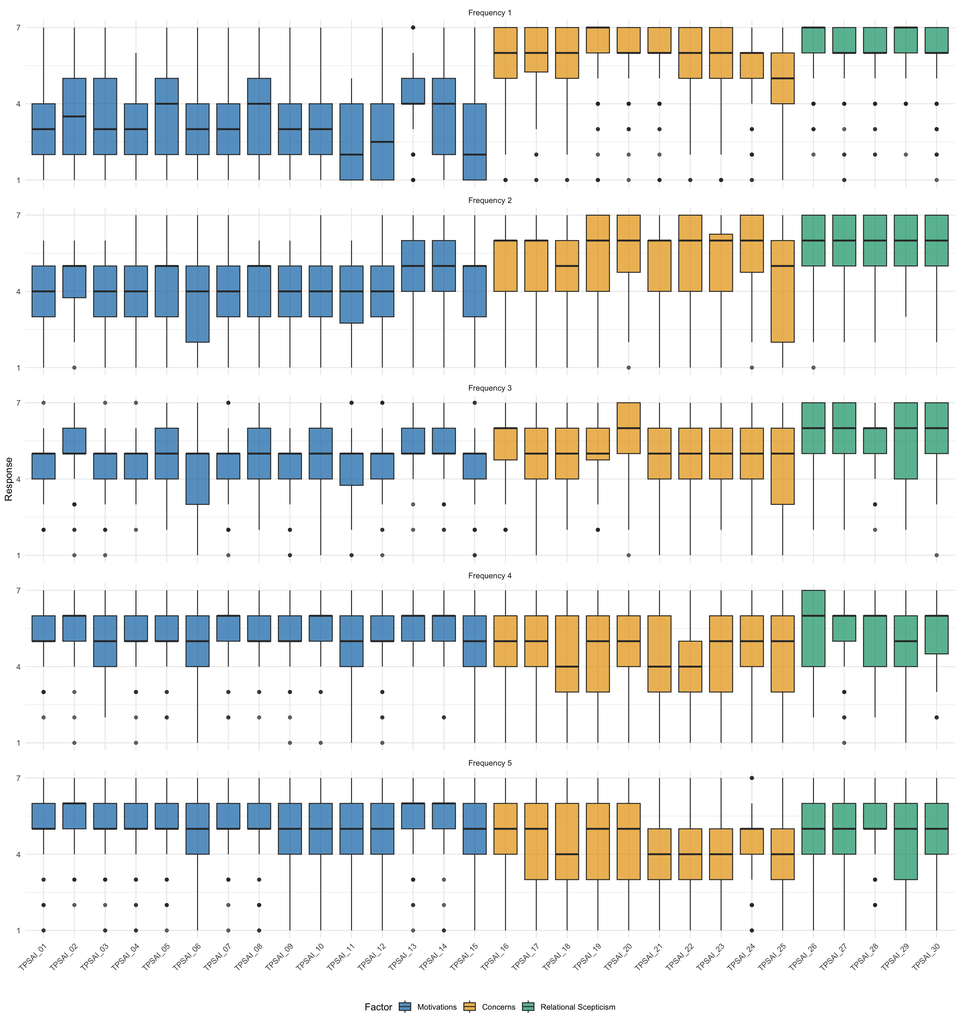

```r
p <- eval_data |>
  select(frequency_level, all_of(cols_tpsai)) |>
  filter(!is.na(frequency_level)) |>
  pivot_longer(-frequency_level, names_to = "item", values_to = "response") |>
  mutate(
    factor = case_when(
      item %in% trust_items ~ "Motivations",
      item %in% risk_items ~ "Concerns",
      item %in% relScept_items ~ "Relational Scepticism",
      .default = NA_character_
    ),
    factor = factor(factor, levels = c("Motivations", "Concerns", "Relational Scepticism")),
    frequency_level = factor(frequency_level, levels = 1:5, labels = paste("Frequency", 1:5))
  ) |>
  ggplot(aes(x = item, y = response, fill = factor)) +
  geom_boxplot(alpha = 0.7) +
  facet_wrap(~ frequency_level, ncol = 1) +
  scale_fill_manual(values = c(
    "Motivations" = "#0072B2",
    "Concerns" = "#E69F00",
    "Relational Scepticism" = "#009E73"
  )) +
  scale_y_continuous(limits = c(1, 7), breaks = c(1, 4, 7)) +
  labs(x = "", y = "Response", fill = "Factor") +
  theme_minimal() +
  theme(
    axis.text.x = element_text(angle = 45, hjust = 1),
    legend.position = "bottom"
  )

p
```

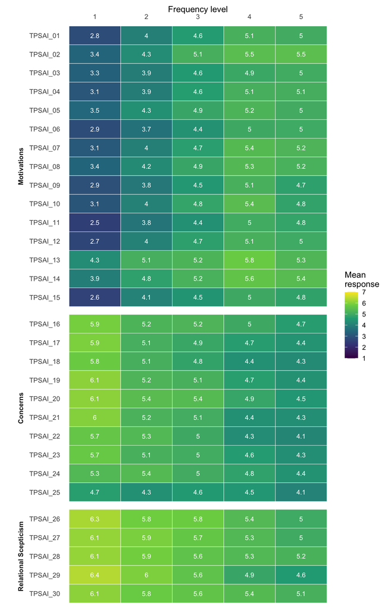

```r
heat <- eval_data |>
  select(frequency_level, all_of(cols_tpsai)) |>
  filter(!is.na(frequency_level)) |>
  pivot_longer(-frequency_level, names_to = "item", values_to = "response") |>
  mutate(
    factor = case_when(
      item %in% trust_items ~ "Motivations",
      item %in% risk_items ~ "Concerns",
      item %in% relScept_items ~ "Relational Scepticism",
      .default = NA_character_
    ),
    factor = factor(factor, levels = c("Motivations", "Concerns", "Relational Scepticism"))
  ) |>
  group_by(frequency_level, item, factor) |>
  summarise(mean = mean(response, na.rm = TRUE), .groups = "drop") |>
  ggplot(aes(x = factor(frequency_level), y = forcats::fct_rev(item), fill = mean)) +
  geom_tile(colour = "white") +
  geom_text(aes(label = round(mean, 1)), size = 3, colour = "white") +
  facet_grid(factor ~ ., scales = "free_y", space = "free_y", switch = "y") +
  scale_fill_viridis_c(limits = c(1, 7), breaks = 1:7) +
  scale_x_discrete(position = "top") +
  labs(x = "Frequency level", y = "", fill = "Mean\nresponse") +
  theme_minimal() +
  theme(
    panel.grid = element_blank(),
    strip.placement = "outside",
    strip.text.y.left = element_text(angle = 90, face = "bold")
  )

heat
```

# Clustering

```r
library(dplyr)
library(tidyr)
library(ggplot2)
library(ggrepel)
library(cluster)
library(mclust)
library(plotly)
library(patchwork)
```

```r
fmt_p <- function(p) ifelse(p < .001, "<.001", sprintf("%.3f", p))
```

```r
X_all <- eval_data |>
  select(motivations_score, concerns_score, rel_scept_score) |>
  as.matrix()
rownames(X_all) <- seq_len(nrow(X_all))
```

## Filtering non-users

```r
groups_all <- cutree(hclust(dist(X_all), method = "ward.D2"), k = 3)

table(groups_all)
```

```
groups_all
  1   2   3
 97 170 135
```

```r
aggregate(X_all, by = list(cluster = groups_all), FUN = function(x) round(mean(x), 2))
```

```
  cluster motivations_score concerns_score rel_scept_score
1       1              5.33           3.43            4.32
2       2              4.79           5.23            5.82
3       3              2.83           6.10            6.51
```

Ward clustering of the full sample gives three profiles ordered along a single gradient:

1. motivated with lower concerns
2. motivated but also concerned and sceptical
3. low motivations with high concerns and scepticism

```r
all_cols <- c("1" = "#1b9e77", "2" = "#d95f02", "3" = "#7570b3")

as.data.frame(X_all) |>
  mutate(cluster = factor(groups_all), id = rownames(X_all)) |>
  plot_ly(
    x = ~motivations_score, y = ~concerns_score, z = ~rel_scept_score,
    color = ~cluster, colors = all_cols,
    type = "scatter3d", mode = "markers",
    marker = list(size = 3, opacity = 0.8),
    text = ~paste0("ID: ", id,
                   "<br>Motivations: ", round(motivations_score, 2),
                   "<br>Concerns: ", round(concerns_score, 2),
                   "<br>Scepticism: ", round(rel_scept_score, 2),
                   "<br>Cluster: ", cluster),
    hoverinfo = "text"
  ) |>
  layout(
    scene = list(xaxis = list(title = "Motivations"),
                 yaxis = list(title = "Concerns"),
                 zaxis = list(title = "Scepticism")),
    legend = list(title = list(text = "Cluster"))
  )
```

[interactive chart not shown]

The three clusters sit next to each other along a curved band with no gaps between them. Cluster 3 (purple) is concentrated at high scepticism and low motivations, with many respondents at the scepticism ceiling.

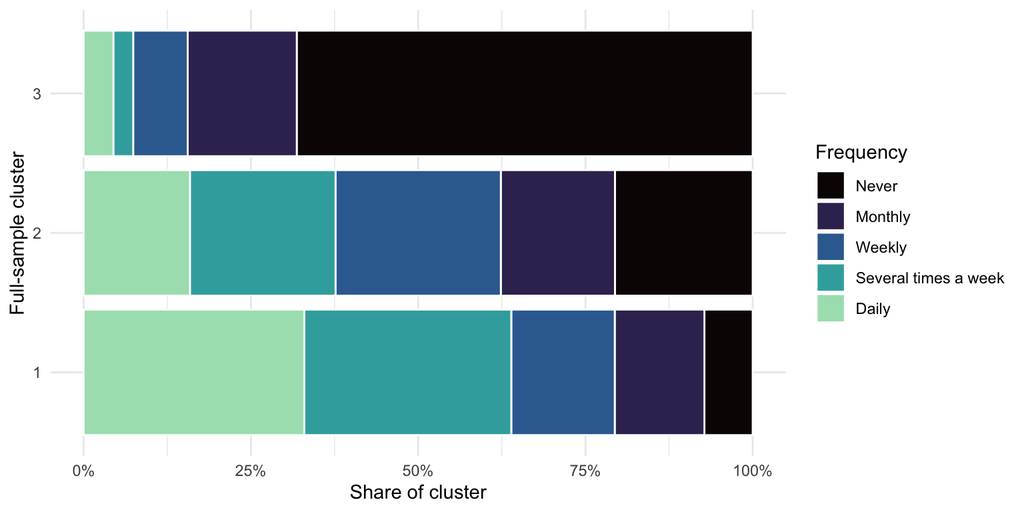

```r
freq_levels <- c("Never", "Monthly", "Weekly", "Several times a week", "Daily")

eval_data |>
  mutate(cluster   = factor(groups_all),
         frequency = factor(frequency_level, levels = 1:5, labels = freq_levels)) |>
  filter(!is.na(frequency)) |>
  dplyr::count(cluster, frequency) |>
  group_by(cluster) |>
  mutate(prop = n / sum(n)) |>
  ggplot(aes(cluster, prop, fill = frequency)) +
  geom_col(colour = "white") +
  scale_fill_viridis_d(option = "mako", end = 0.9) +
  scale_y_continuous(labels = scales::percent) +
  labs(x = "Full-sample cluster", y = "Share of cluster", fill = "Frequency") +
  coord_flip() +
  theme_minimal()
```

```r
eval_data |>
  mutate(cluster = factor(groups_all)) |>
  filter(!is.na(frequency_level)) |>
  group_by(cluster) |>
  summarise(n         = n(),
            non_users = sum(frequency_level == 1),
            pct       = sprintf("%.0f%%", 100 * non_users / n)) |>
  knitr::kable()
```

| cluster | n | non_users | pct |
| --- | --- | --- | --- |
| 1 | 97 | 7 | 7% |
| 2 | 170 | 35 | 21% |
| 3 | 135 | 92 | 68% |

```r
non_user <- eval_data$frequency_level == 1
mean(groups_all[which(non_user)] == 3)
```

```
[1] 0.6865672
```

Cluster 3 is made up mostly of non-users: 68% of its members never use generative AI for psychological support, compared with 21% of cluster 2 and 7% of cluster 1. In the full sample, the sceptical end of the gradient therefore largely reflects not using AI for support at all, rather than a distinct attitude among people who do.

Non-users are excluded from the rest of the analysis for several reasons:

- the analysis that follows asks whether there are distinct attitude profiles among people who actually use AI for psychological support
- including non-users would confound differences in attitudes with differences in use, which matters most for the dependency outcomes compared below
- most TPSai items describe experiences of using AI for support (for example, “I feel calmer when I talk to the AI while distressed”), so non-users’ answers are hypothetical rather than based on experience

```r
users  <- which(eval_data$frequency_level > 1)
u_data <- eval_data[users, ]
X      <- X_all[users, ]

nrow(X)
```

```
[1] 268
```

## No standardisation needed

```r
round(apply(X, 2, sd), 2)
```

```
motivations_score    concerns_score   rel_scept_score
             1.01              1.21              1.11
```

Ward clustering uses Euclidean distances, so a score with a larger spread has more influence on which respondents are grouped together. The standard deviations among users are similar, so no single score dominates the distances.

```r
round(cor(X), 2)
```

```
                  motivations_score concerns_score rel_scept_score
motivations_score              1.00          -0.47           -0.45
concerns_score                -0.47           1.00            0.67
rel_scept_score               -0.45           0.67            1.00
```

Concerns and scepticism are strongly correlated, and motivations is negatively correlated with both. The scores share a common structure rather than measuring three unrelated things.

All three scores are measured on the same 1–7 response scale, so a one-point difference has the same meaning on each, and the clusters can be described directly in scale points. The raw scores are therefore kept, and a standardised solution is included as a robustness check.

## Clusters

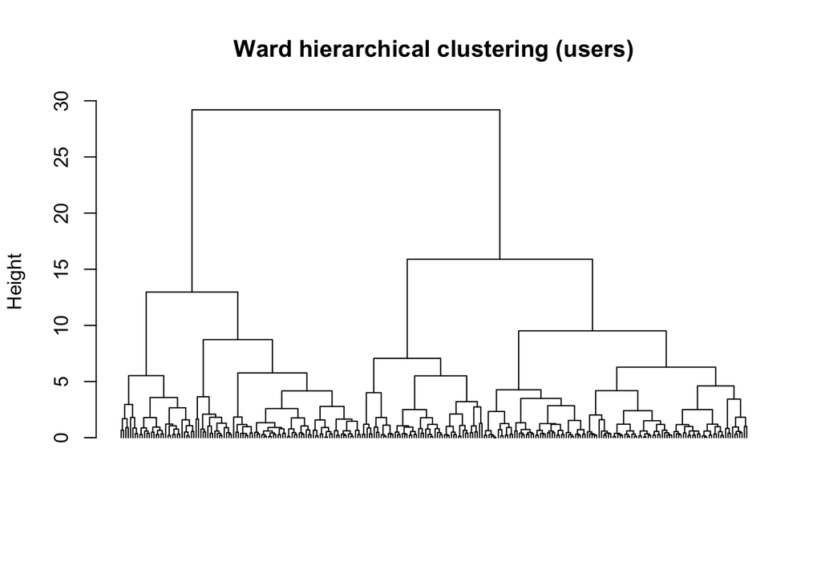

```r
d  <- dist(X)
hc <- hclust(d, method = "ward.D2")

plot(hc, labels = FALSE, hang = -1,
     main = "Ward hierarchical clustering (users)", xlab = "", sub = "")
```

The largest gap in merge heights falls between the final merge (around 29) and the next one down (around 16), supporting two clusters. Below that, merges at around 16, 13, 9.5 and 8.7 are evenly spaced, so no further cut stands out.

```r
data.frame(
  k       = 2:6,
  avg_sil = sapply(2:6, function(kk)
    round(summary(silhouette(cutree(hc, kk), d))$avg.width, 3))
)
```

```
  k avg_sil
1 2   0.356
2 3   0.284
3 4   0.259
4 5   0.216
5 6   0.240
```

Average silhouette width is highest for two clusters (0.36) and drops clearly for three (0.28), close to the level usually treated as negligible structure. Two clusters are retained.

```r
k <- 2
groups <- cutree(hc, k = k)
```

## Profiles

```r
table(groups)
```

```
groups
  1   2
103 165
```

```r
aggregate(X, by = list(cluster = groups), FUN = function(x) round(mean(x), 2))
```

```
  cluster motivations_score concerns_score rel_scept_score
1       1              5.28           3.64            4.42
2       2              4.51           5.49            6.06
```

The two clusters correspond to two profiles of users:

1. **Confident (green):** motivated, with moderate concerns and scepticism
2. **Cautious (orange):** still motivated, but with high concerns and scepticism

Both groups score above the scale midpoint on motivations. What separates them is concerns and scepticism, which differ by more than twice as much as motivations.

```r
profile_labels <- c("Confident", "Cautious")
cluster_cols   <- c("Confident" = "#1b9e77", "Cautious" = "#d95f02")
```

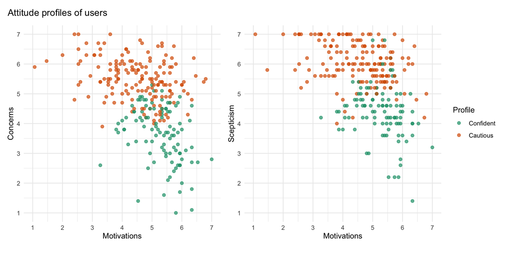

```r
score_panel <- function(df, y, y_label, cols, legend_title) {
  ggplot(df, aes(motivations_score, .data[[y]], colour = cluster)) +
    geom_point(alpha = 0.7, size = 1.8) +
    scale_colour_manual(values = cols) +
    scale_x_continuous(breaks = 1:7) +
    scale_y_continuous(breaks = 1:7) +
    coord_equal(xlim = c(1, 7), ylim = c(1, 7)) +
    labs(x = "Motivations", y = y_label, colour = legend_title) +
    theme_minimal()
}

cluster_f <- factor(groups, levels = 1:2, labels = profile_labels)
users_df  <- as.data.frame(X) |> mutate(cluster = cluster_f)

score_panel(users_df, "concerns_score", "Concerns", cluster_cols, "Profile") +
  score_panel(users_df, "rel_scept_score", "Scepticism", cluster_cols, "Profile") +
  plot_layout(guides = "collect") +
  plot_annotation(title = "Attitude profiles of users")
```

The boundary between the profiles runs mainly along the concerns and scepticism axes rather than along motivations.

```r
as.data.frame(X) |>
  mutate(cluster = cluster_f, id = rownames(X)) |>
  plot_ly(
    x = ~motivations_score, y = ~concerns_score, z = ~rel_scept_score,
    color = ~cluster, colors = cluster_cols,
    type = "scatter3d", mode = "markers",
    marker = list(size = 3, opacity = 0.8),
    text = ~paste0("ID: ", id,
                   "<br>Motivations: ", round(motivations_score, 2),
                   "<br>Concerns: ", round(concerns_score, 2),
                   "<br>Scepticism: ", round(rel_scept_score, 2),
                   "<br>Profile: ", cluster),
    hoverinfo = "text"
  ) |>
  layout(
    title = "Attitude profiles of users",
    scene = list(
      xaxis = list(title = "Motivations", range = c(1, 7)),
      yaxis = list(title = "Concerns", range = c(1, 7)),
      zaxis = list(title = "Scepticism", range = c(1, 7)),
      aspectmode = "cube"
    ),
    legend = list(title = list(text = "Profile"))
  )
```

[interactive chart not shown]

## Continuum vs groups

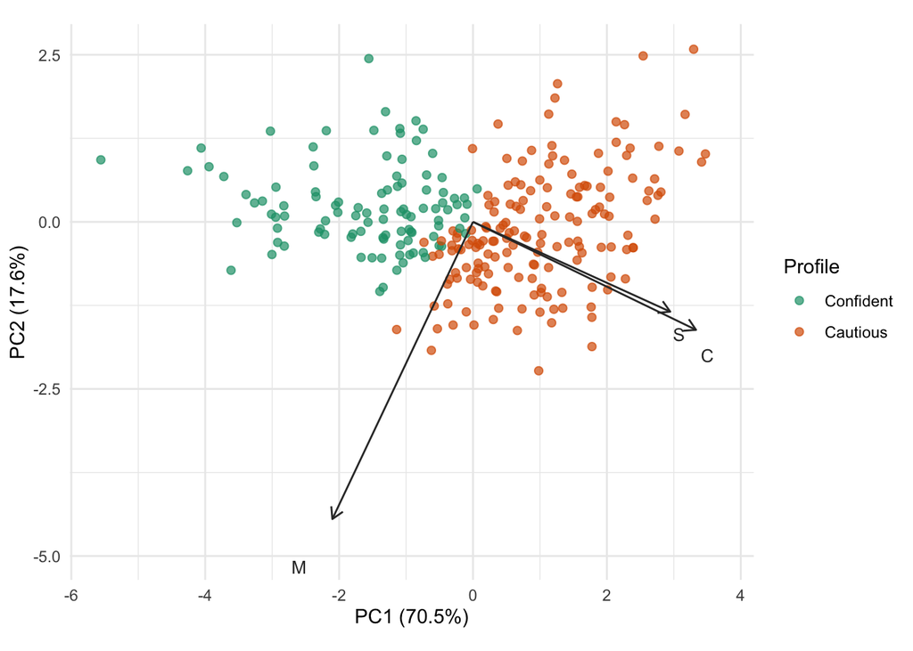

```r
pca <- prcomp(X, center = TRUE, scale. = FALSE)
ve  <- round(100 * pca$sdev^2 / sum(pca$sdev^2), 1)

arrow_scale <- 0.8 * max(abs(pca$x[, 1:2])) / max(abs(pca$rotation[, 1:2]))
load_df <- data.frame(
  var = c("M", "C", "S"),
  PC1 = pca$rotation[, 1] * arrow_scale,
  PC2 = pca$rotation[, 2] * arrow_scale
)

ggplot(data.frame(pca$x[, 1:2], cluster = cluster_f),
       aes(PC1, PC2, colour = cluster)) +
  geom_point(alpha = 0.7, size = 1.8) +
  geom_segment(data = load_df, aes(0, 0, xend = PC1, yend = PC2),
               inherit.aes = FALSE, colour = "grey20",
               arrow = arrow(length = unit(0.25, "cm"))) +
  geom_text_repel(data = load_df, aes(PC1 * 1.12, PC2 * 1.12, label = var),
                  inherit.aes = FALSE, colour = "grey20", size = 3.5) +
  scale_colour_manual(values = cluster_cols) +
  labs(x = paste0("PC1 (", ve[1], "%)"), y = paste0("PC2 (", ve[2], "%)"),
       colour = "Profile") +
  coord_equal() +
  theme_minimal()
```

The two profiles sit side by side along the first principal component, with no gap between them.

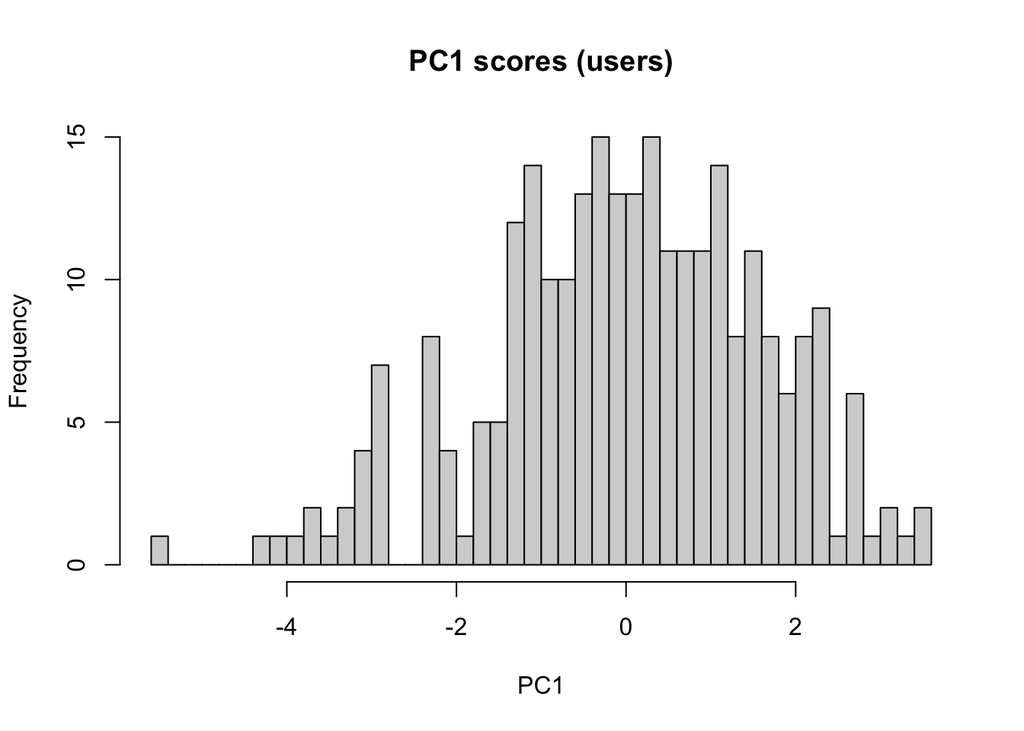

```r
hist(pca$x[, 1], breaks = 40, main = "PC1 scores (users)", xlab = "PC1")
```

PC1 scores have a single hump rather than two, so the profiles are best understood as two regions of a continuum rather than discrete types. Together with the modest silhouette width (0.36), the profiles are presented as a descriptive summary of where users sit on that continuum.

## Robustness

```r
table(full_sample = groups_all[users], users = groups)
```

```
           users
full_sample   1   2
          1  90   0
          2  13 122
          3   0  43
```

The users-only solution closely reproduces the full-sample structure. All users from full-sample cluster 1 fall into the confident profile, and all users from full-sample cluster 3 join the cautious profile, together with almost all users from cluster 2. Only 13 of 268 users cross the boundary. The distinction between confident and cautious users therefore reappears almost unchanged when clustering is rerun from scratch on a different sample, while the full-sample boundary between clusters 2 and 3 disappears once non-users are excluded.

```r
set.seed(1)
methods <- list(
  ward        = groups,
  ward_scaled = cutree(hclust(dist(scale(X)), method = "ward.D2"), k = k),
  kmeans      = kmeans(X, centers = k, nstart = 50)$cluster,
  pam         = pam(X, k = k)$clustering,
  gmm         = Mclust(X, G = k, verbose = FALSE)$classification
)

ari <- outer(names(methods), names(methods), Vectorize(function(a, b)
  adjustedRandIndex(methods[[a]], methods[[b]])))
dimnames(ari) <- list(names(methods), names(methods))
round(ari, 2)
```

```
            ward ward_scaled kmeans  pam  gmm
ward        1.00        0.83   0.65 0.72 0.34
ward_scaled 0.83        1.00   0.67 0.72 0.29
kmeans      0.65        0.67   1.00 0.86 0.36
pam         0.72        0.72   0.86 1.00 0.36
gmm         0.34        0.29   0.36 0.36 1.00
```

The adjusted Rand index shows how closely each pair of methods agrees, from 0 (chance) to 1 (identical). The first row shows how closely each alternative reproduces the Ward solution.

## Profile differences

```r
u_data <- u_data |>
  mutate(cluster   = cluster_f,
         frequency = factor(frequency_level, levels = 2:5, labels = freq_levels[2:5]))
```

### Usage frequency

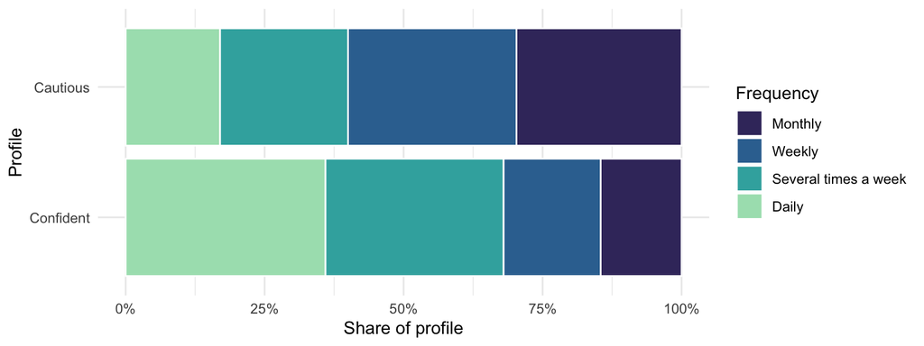

```r
u_data |>
  dplyr::count(cluster, frequency) |>
  group_by(cluster) |>
  mutate(prop = n / sum(n)) |>
  ggplot(aes(cluster, prop, fill = frequency)) +
  geom_col(colour = "white") +
  scale_fill_viridis_d(option = "mako", begin = 0.25, end = 0.9) +
  scale_y_continuous(labels = scales::percent) +
  labs(x = "Profile", y = "Share of profile", fill = "Frequency") +
  coord_flip() +
  theme_minimal()
```

```r
u_data |>
  dplyr::count(cluster, frequency, .drop = FALSE) |>
  group_by(cluster) |>
  mutate(pct = sprintf("%.0f%%", 100 * n / sum(n))) |>
  select(-n) |>
  pivot_wider(names_from = frequency, values_from = pct) |>
  knitr::kable()
```

| cluster | Monthly | Weekly | Several times a week | Daily |
| --- | --- | --- | --- | --- |
| Confident | 15% | 17% | 32% | 36% |
| Cautious | 30% | 30% | 23% | 17% |

Frequency is ordinal, so it is shown as the share of each profile at each level rather than as a mean. Each row sums to 100%.

```r
f1 <- as.integer(u_data$frequency[u_data$cluster == "Confident"])
f2 <- as.integer(u_data$frequency[u_data$cluster == "Cautious"])
wt <- wilcox.test(f1, f2, exact = FALSE)

tibble(
  W          = unname(wt$statistic),
  p          = fmt_p(wt$p.value),
  r_rb       = round(2 * unname(wt$statistic) / (sum(!is.na(f1)) * sum(!is.na(f2))) - 1, 2)
) |>
  knitr::kable()
```

| W | p | r_rb |
| --- | --- | --- |
| 11180.5 | <.001 | 0.32 |

The Wilcoxon rank-sum test compares frequency between the two profiles without treating the categories as equally spaced. The rank-biserial correlation (r_rb) is the effect size: it ranges from −1 to 1, and positive values mean confident users use AI for support more often.

**Confident users use AI for support considerably more often.** 68% of them use it several times a week or daily, compared with 40% of cautious users. Cautious users are spread fairly evenly from monthly to daily, with the largest shares at monthly and weekly (30% each). The rank-biserial correlation of 0.32 is a moderate effect.

### Generative AI dependency (GAID)

GAID measures three facets of dependency on generative AI: cognitive preoccupation (persistent mental engagement and urges to use it), negative consequences (concerns about reliance, reduced performance and self-efficacy) and withdrawal (distress when access is restricted). Items are rated on a 5-point scale. Factor scores are the mean of their items, and the overall score is the mean of the three factor scores.

GAID asks about generative AI in general, not about its use for psychological support specifically, so it is used here as a proxy. Dependency on AI for psychological support may differ and is left for qualitative exploration.

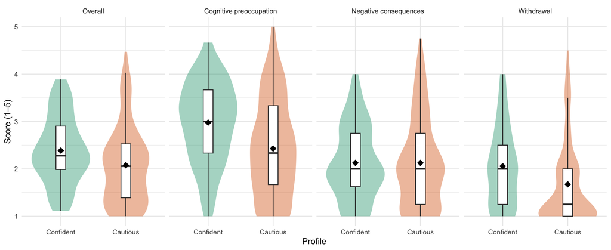

```r
gaid_map <- tibble(
  item   = sprintf("GAID_%d", 1:11),
  factor = rep(c("GAID_CogPre", "GAID_NegCons", "GAID_Withdrawal"),
               times = c(3, 4, 4))
)

gaid_scores <- sapply(split(gaid_map$item, gaid_map$factor),
                      function(items) rowMeans(u_data[, items]))

gaid_long <- as.data.frame(gaid_scores) |>
  mutate(GAID_Overall = rowMeans(across(everything())),
         cluster      = cluster_f) |>
  pivot_longer(-cluster, names_to = "measure", values_to = "score") |>
  mutate(measure = factor(measure,
    levels = c("GAID_Overall", "GAID_CogPre", "GAID_NegCons", "GAID_Withdrawal"),
    labels = c("Overall", "Cognitive preoccupation",
               "Negative consequences", "Withdrawal")))

ggplot(gaid_long, aes(cluster, score, fill = cluster)) +
  geom_violin(alpha = 0.4, colour = NA, na.rm = TRUE) +
  geom_boxplot(width = 0.15, outlier.shape = NA, fill = "white", na.rm = TRUE) +
  stat_summary(fun = mean, geom = "point", shape = 23, size = 2.5,
               fill = "black", na.rm = TRUE) +
  facet_wrap(~ measure, nrow = 1) +
  scale_fill_manual(values = cluster_cols, guide = "none") +
  scale_y_continuous(limits = c(1, 5), breaks = 1:5) +
  labs(x = "Profile", y = "Score (1–5)") +
  theme_minimal()
```

```r
gaid_long |>
  group_by(measure) |>
  group_modify(~ {
    a  <- .x$score[.x$cluster == "Confident"]
    b  <- .x$score[.x$cluster == "Cautious"]
    a  <- a[!is.na(a)]
    b  <- b[!is.na(b)]
    tt <- t.test(a, b, var.equal = FALSE)
    sp <- sqrt(((length(a) - 1) * var(a) + (length(b) - 1) * var(b)) /
                 (length(a) + length(b) - 2))
    tibble(
      Confident   = sprintf("%.2f (%.2f)", mean(a), sd(a)),
      Cautious = sprintf("%.2f (%.2f)", mean(b), sd(b)),
      `t (df)`   = sprintf("%.2f (%.0f)", tt$statistic, tt$parameter),
      p          = tt$p.value,
      d          = round((mean(a) - mean(b)) / sp, 2)
    )
  }) |>
  ungroup() |>
  mutate(p = fmt_p(p.adjust(p, method = "holm"))) |>
  rename(Measure = measure) |>
  knitr::kable()
```

| Measure | Confident | Cautious | t (df) | p | d |
| --- | --- | --- | --- | --- | --- |
| Overall | 2.39 (0.71) | 2.08 (0.83) | 3.27 (241) | 0.003 | 0.40 |
| Cognitive preoccupation | 2.98 (0.86) | 2.43 (1.02) | 4.74 (244) | <.001 | 0.57 |
| Negative consequences | 2.13 (0.77) | 2.13 (0.94) | 0.00 (247) | 0.997 | 0.00 |
| Withdrawal | 2.06 (0.83) | 1.67 (0.87) | 3.59 (223) | 0.001 | 0.45 |

Each row compares the two profiles on one GAID score. The profile columns give the mean (SD). The t statistic comes from Welch’s t-test, which does not assume equal variances, and p-values are Holm-adjusted across the four scores. Cohen’s d is the standardised difference in means: positive values mean confident users score higher, and values around 0.2, 0.5 and 0.8 are conventionally read as small, medium and large.

Confident users scored higher than cautious users on overall dependency (d = 0.40), cognitive preoccupation (d = 0.57) and withdrawal (d = 0.45), all small-to-medium differences that remained significant after Holm correction. The two profiles did not differ on negative consequences (2.13 in both groups, d = 0.00). One reading is that TPSai concerns are mainly about AI as a mental-health tool rather than about the effects of one’s own use. Dependency was low in both profiles, with most means around 2 on the 1–5 scale, so these are differences between low levels of dependency rather than between dependent and non-dependent users.

Confident users use AI for support more often, and dependency is likely to increase with use, so the profile differences in GAID scores may partly reflect frequency of use rather than attitudes. Each GAID score is therefore regressed on profile and usage frequency together. The estimate is the difference between cautious and confident users at the same frequency of use, so negative values mean confident users score higher. The p-values are not adjusted for multiple comparisons.

```r
gaid_wide <- as.data.frame(gaid_scores) |>
  mutate(GAID_Overall = rowMeans(across(everything())),
         cluster      = cluster_f,
         frequency    = u_data$frequency)

sapply(c("GAID_Overall", "GAID_CogPre", "GAID_NegCons", "GAID_Withdrawal"), function(v) {
  fit <- lm(reformulate(c("cluster", "frequency"), response = v), data = gaid_wide)
  round(coef(summary(fit))["clusterCautious", c("Estimate", "Pr(>|t|)")], 3)
})
```

```
         GAID_Overall GAID_CogPre GAID_NegCons GAID_Withdrawal
Estimate       -0.131      -0.325        0.120          -0.187
Pr(>|t|)        0.172       0.006        0.289           0.074
```

Adjusting for frequency roughly halves most of the differences. Cognitive preoccupation is the only score on which the profiles still clearly differ: at the same frequency of use, confident users score about a third of a point higher (b = −0.33, p = .006), and this difference remains significant after Holm correction across the four scores. The differences in overall dependency (b = −0.13, p = .172) and withdrawal (b = −0.19, p = .074) shrink and are no longer significant, so confident users score higher on these largely because they use AI more often. For negative consequences, cautious users score slightly higher once frequency is held constant (b = 0.12, p = .289). This is the predicted direction, but the difference is small and not significant.

Frequency is probably not only a confounder. More confident attitudes plausibly lead to more frequent use, which in turn leads to more dependency, so adjusting for frequency removes part of a genuine effect of the profiles. The adjusted results therefore do not show that the unadjusted differences are spurious. Rather, they suggest that the profiles’ differences in dependency operate largely through how often people use generative AI, with cognitive preoccupation the one facet related to attitudes beyond frequency of use.